# PSTAT126: Part 4 Collinearity

Chris Park, Justin McCarthy, James San, Shengnan Liu

2023-06-03

## Shrinkage Model/collinearity

Since in our model we got values almost equal to 1, this showed there is almost no collinearity between log(creatinine_phosphokinase) and log(serum_sodium).

```r
library('faraway')
heart <- read.csv("heart_failure_clinical_records_dataset.csv")
c <- data.frame(log(heart$creatinine_phosphokinase), log(heart$serum_sodium))
vif(c)
```

```
## log.heart.creatinine_phosphokinase.             log.heart.serum_sodium.
##                            1.000279                            1.000279
```

## Lasso and Ridge Regression

Since the differences are only millesimal or centesimal between the coefficients of MLR and those of Lasso, respectively, the best Lasso lambda is 0.00058 which is extremely close to 0, our Lasso model turns out to be almost identical to MLR model.

Since MSE of both Lasso and RR are small (both between 0.19 and 0.21), our Lasso and RR models predict the dataset fairly accurately as a whole.

```r
library('glmnet')
#define matrix of predictor variables
mat1.data <- c(log(heart$creatinine_phosphokinase),log(heart$serum_sodium))
mat1 <- matrix(mat1.data,nrow=299,ncol=2,byrow=FALSE)

#define response variable
y <- log(heart$serum_creatinine)

library('glmnet')

#fit lasso regression model using k-fold cross-validation
lasso_cv_model <- cv.glmnet(mat1, y, alpha = 1)
lasso_cv_model
```

```
##
## Call:  cv.glmnet(x = mat1, y = y, alpha = 1)
##
## Measure: Mean-Squared Error
##
##      Lambda Index Measure      SE Nonzero
## min 0.00058    58  0.1941 0.02893       2
## 1se 0.11732     1  0.2058 0.02862       0
```

```r
#find optimal lambda value that minimizes test MSE
lasso_best_lambda <- lasso_cv_model$lambda.min
lasso_best_lambda
```

```
## [1] 0.0005838811
```

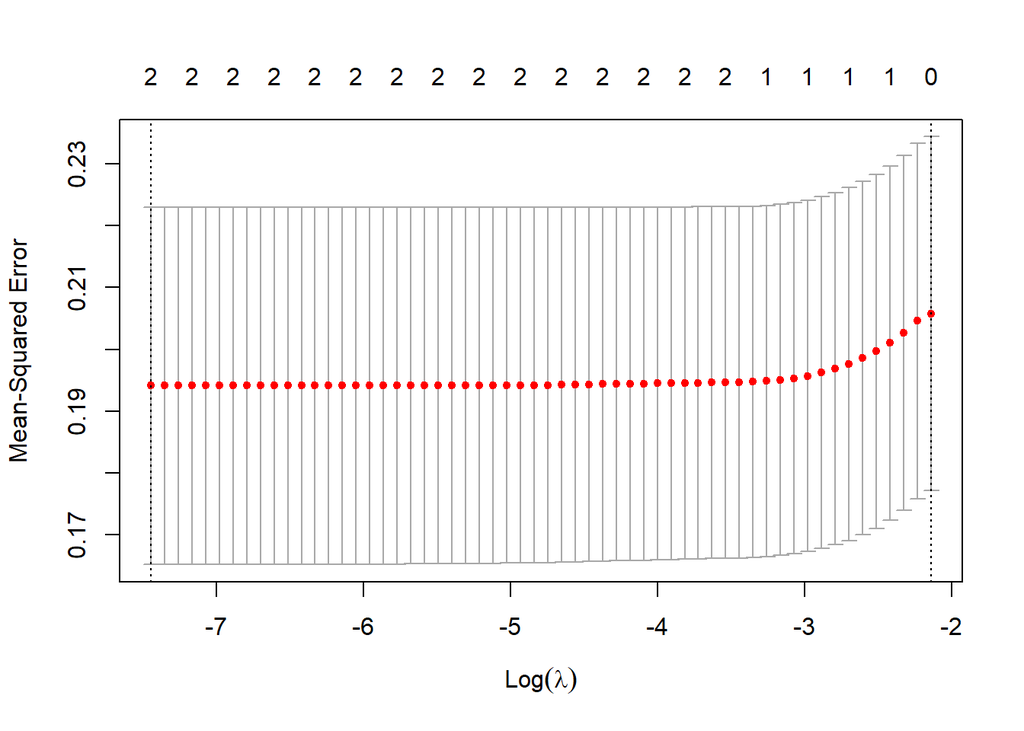

```r
#produce plot of test MSE by lambda value
plot(lasso_cv_model)
```

```r
#find coefficients of best model
lasso_best_model <- glmnet(mat1, y, alpha = 1, lambda = lasso_best_lambda)
coef(lasso_best_model)
```

```
## 3 x 1 sparse Matrix of class "dgCMatrix"
##                      s0
## (Intercept) 17.71785320
## V1          -0.02525141
## V2          -3.53414128
```

```r
#define matrix of predictor variables
mat1.data <- c(log(heart$creatinine_phosphokinase),log(heart$serum_sodium))
mat1 <- matrix(mat1.data,nrow=299,ncol=2,byrow=FALSE)

#define response variable
y <- log(heart$serum_creatinine)

#fit lasso regression model using k-fold cross-validation
ridge_cv_model <- cv.glmnet(mat1, y, alpha = 0)
ridge_cv_model
```

```
##
## Call:  cv.glmnet(x = mat1, y = y, alpha = 0)
##
## Measure: Mean-Squared Error
##
##     Lambda Index Measure      SE Nonzero
## min   0.11    76  0.1955 0.03044       2
## 1se 117.32     1  0.2058 0.03155       2
```

```r
#find optimal lambda value that minimizes test MSE
ridge_best_lambda <- ridge_cv_model$lambda.min
ridge_best_lambda
```

```
## [1] 0.1094087
```

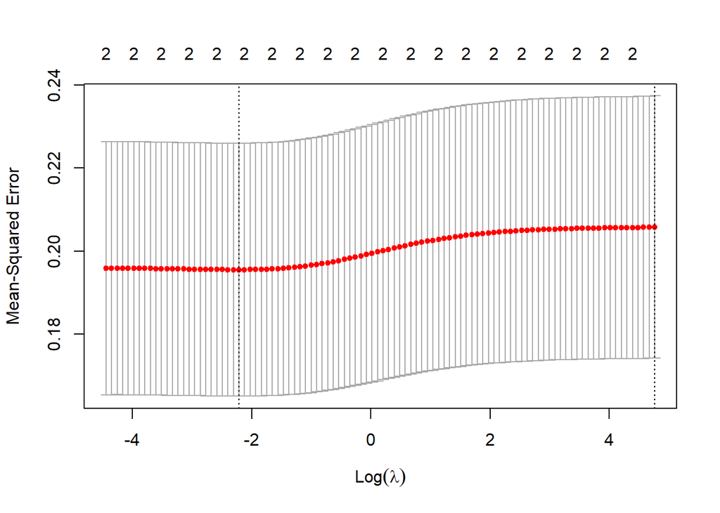

```r
#produce plot of test MSE by lambda value
plot(ridge_cv_model)
```

```r
#find coefficients of best model
ridge_best_model <- glmnet(mat1, y, alpha = 0, lambda = ridge_best_lambda)
coef(ridge_best_model)
```

```
## 3 x 1 sparse Matrix of class "dgCMatrix"
##                      s0
## (Intercept) 14.38954793
## V1          -0.02101114
## V2          -2.86208494
```